# ＃Pythonの特徴

## 5. for文

指定回数を繰り返して処理を行いたい時には、for文を使う。 （while文を使う方法もある。)

#### 構文の書き方 ① 「単純な繰り返し処理」

for 変数 in range([始まりの数値=0,] 最後の数値[, 増加する量=1]): 処理内容

■構文例

```python
# 以下の処理を5回繰り返す
for i in range(5):
    #数字を表示する（数字は1づつ増加）
    print(i)
```

```
0
1
2
3
4
```

```python
# 始まりの数値を1、増加量を2にしたい場合
for i in range(1, 5, 2):
    print(i)
```

```
1
3
```

#### 構文の書き方 ② 「データの集まりに対して繰り返し処理」

for 変数 in データの集まり: （リスト、文字列） 処理

■構文例: 文字列

```python
#変数charにはHello Worldの文字が順番に代入される
for char in "Hello World":
    print(char)
```

```
H
e
l
l
o

W
o
r
l
d
```

■構文例: リスト

```python
list_num = [0, 1, 2, 3, 4]
```

```python
 #変数numにはlist_numの要素が添字順に代入される
for num in list_num:
    print(num)
```

```
0
1
2
3
4
```

#### ＜リストの繰り返し処理のメリット例＞

■問題3の3 for文なし

```python
score = [80, 50, 90]
total = score[0] + score[1] + score[2]  # 長い
print(total)
```

```
220
```

■問題3の3 for文あり

```python
score = [80, 50, 90]
total = 0
for num in score:
    total += num
print(total)
```

```
220
```

#### 問題５： 以下の問題を解いてみましょう（5分）

1. 空のリストlist_numに要素0~5を順番に追加(append)し、追加するたびにlist_numを出力する。  
   <出力例>  
   [0]  
   [0, 1]  
   [0, 1, 2]  
   [0, 1, 2, 3]  
   [0, 1, 2, 3, 4]  
   [0, 1, 2, 3, 4, 5]

```python
list_num = []
for i in range(6):
    list_num.append(i)
    print(list_num)
```

```
[0]
[0, 1]
[0, 1, 2]
[0, 1, 2, 3]
[0, 1, 2, 3, 4]
[0, 1, 2, 3, 4, 5]
```

1. list_numに要素6,8,10を順番に追加(append)して、追加するたびにlist_numを出力する。  
   <出力例>  
   [0, 1, 2, 3, 4, 5, 6]  
   [0, 1, 2, 3, 4, 5, 6, 8]  
   [0, 1, 2, 3, 4, 5, 6, 8, 10]

```python
for i in range(6,11,2):
    list_num.append(i)
    print(list_num)
```

```
[0, 1, 2, 3, 4, 5, 6]
[0, 1, 2, 3, 4, 5, 6, 8]
[0, 1, 2, 3, 4, 5, 6, 8, 10]
```

1. list_numの要素を全て足し合わせた値を変数totalに代入し、変数totalを出力する。

```python
for num in list_num:
    total += num
print(total)
```

```
259
```

## 6. 関数

関数とは「何らかの値を渡すと、その値に応じた何らかの値を返すもの」と定義される。  
関数に渡す何らかの値のことを「引数」、関数から返ってくる何らかの値のことを「戻り値」という。  
Pythonにデフォルトで定義されている関数の代表例にはprint()関数がある。

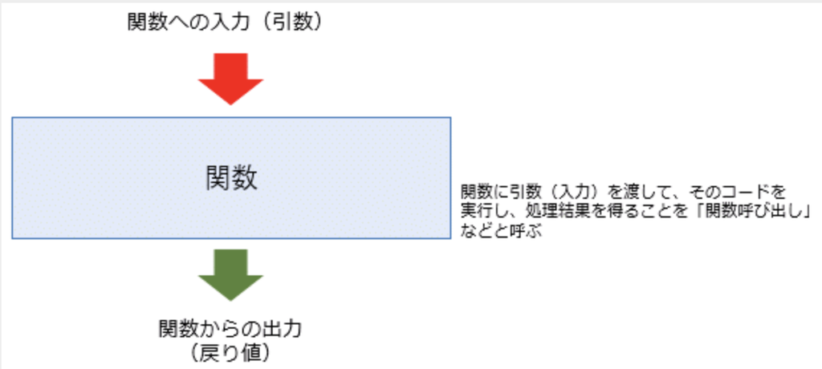

Pythonではdef文を用いてユーザーが関数を定義することができる。  
def文の構文の書き方の例は以下の通りである。

def 関数名(仮引数1, 仮引数2, ...): 処理名 return 戻り値 変数 = 関数名(実引数1, 実引数2, ...)

```python
# 仮引数x, yの合計値を戻り値として返す
def add(x, y):
    sum = x + y
    return sum

# add関数を呼び出し、戻り値を変数totalに代入
total = add(3, 8)
print(total)
```

[output not shown]

#### 問題６：以下の問題を解いてみましょう（10分）

■fizzbuzz問題  
呼び出し元から1~50までの値が順番に渡され、渡された値が  
・3の倍数の時: "Fizz"と出力  
・5の倍数の時: "Buzz"と出力  
・3と５の公倍数の時: "FizzBuzz"と出力  
という処理を行うプログラムを関数を用いて作成してみましょう。

```python
# fizzbuzz関数
def fizzbuzz(num):
    if num % 3 == 0 and num % 5 == 0:
        print("FizzBuzz")
    elif num % 3 == 0:
        print("Fizz")
    elif num % 5 == 0:
        print("Buzz")
    else:
        print(num)

# 呼び出し元
for i in range(1,51):
    fizzbuzz(i)
```

```
1
2
Fizz
4
Buzz
Fizz
7
8
Fizz
Buzz
11
Fizz
13
14
FizzBuzz
16
17
Fizz
19
Buzz
Fizz
22
23
Fizz
Buzz
26
Fizz
28
29
FizzBuzz
31
32
Fizz
34
Buzz
Fizz
37
38
Fizz
Buzz
41
Fizz
43
44
FizzBuzz
46
47
Fizz
49
Buzz
```

## 時間があればやってみてください

### 1. ProgateのPython講座で復習する（レッスン1~3）

### 2. ProgateのPython講座でさらに勉強する（レッスン4~5）

https://prog-8.com/

# 今後の予定

## 第5回 OpenCV実践

## 第6回 教師あり/なし学習について（座学）

## 第7回 ニューラルネットワークについて（座学）

## 第8回 画像解析アルゴリズムの応用（AIエンジの取り組み）（座学）

## 第9回 画像分類実践

## 第10回 物体検出実践

## 第11回以降 やってみたをやってみよう